# SME0806 - Estatística Computacional - Trabalho 1

Matheus Victal Cerqueira

20/05/2021

## Introdução

O presente documento se trata de uma solução para os exercícios propostos no Trabalho 1 da disciplina SME0806 - Estatística Computacional, oferecida pelo Instituto de Ciências Matemáticas e de Computação da Universidade de São Paulo no primeiro semestre de 2021. As temáticas abordadas são métodos computacionais para a geração de amostras aleatórias e aplicação de simulações de Monte Carlo para a resolução de problemas estatísticos.

## Desenvolvimento e Metodologia

### Exercício 1

É notório que a função $q(x)$ se trata de um *kernel* para uma função de distribuição, e para obter uma função de distribuição de fato seria necerrária a multiplicação de $q(x)$ por uma contante normalizadora. Porém, pode-se gerar amostras pseudoaleatórias de $X$ apenas com o conhecimento da função *kernel* $q(x)$, e por tal motivo, não será obtido o valor de tal constante no decorrer desta solução.

Tal função $g(y)$ é interessante para a resolução do problema via método da aceitação-rejeição devido ao fato de podermos gerar amostras psudoaleatórias dela facilmente pelo método da inversão e pelo fato de seu comportamento permitir que ela, ao ser multiplicada por um fator $M$, seja capaz de envelopar $q(x)$, condição necessária para a aplicação do método. Abaixo encontram-se gráficos para $q(x)$ e $g(y)$. Repare que ambas possuem o mesmo domínio $\mathbb{R}$.

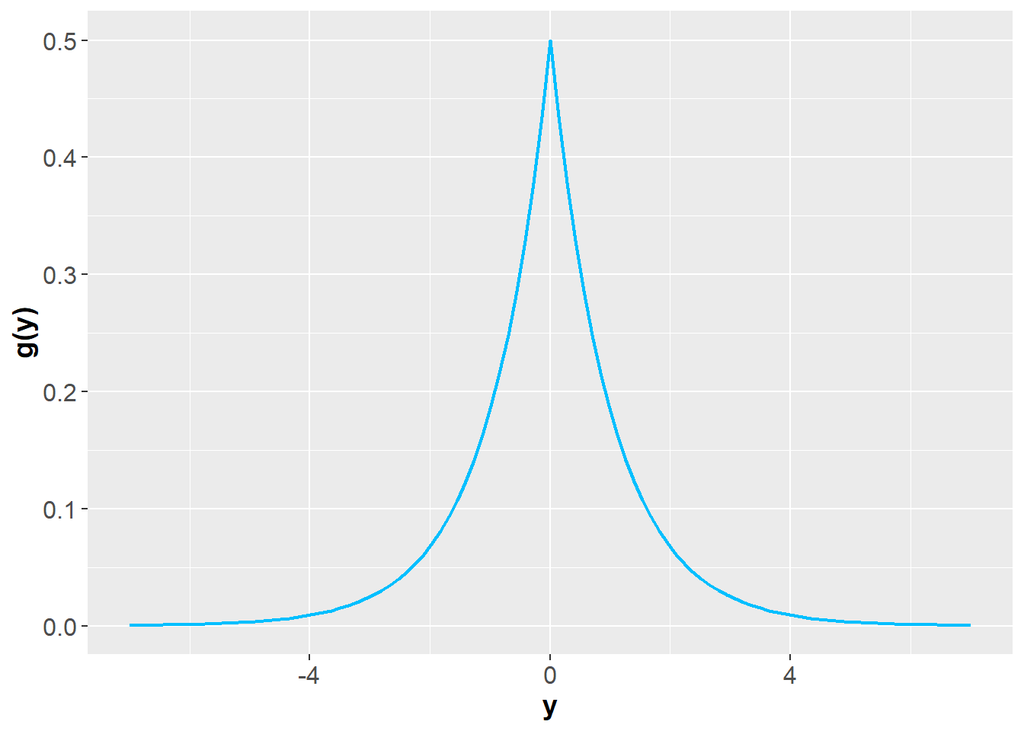

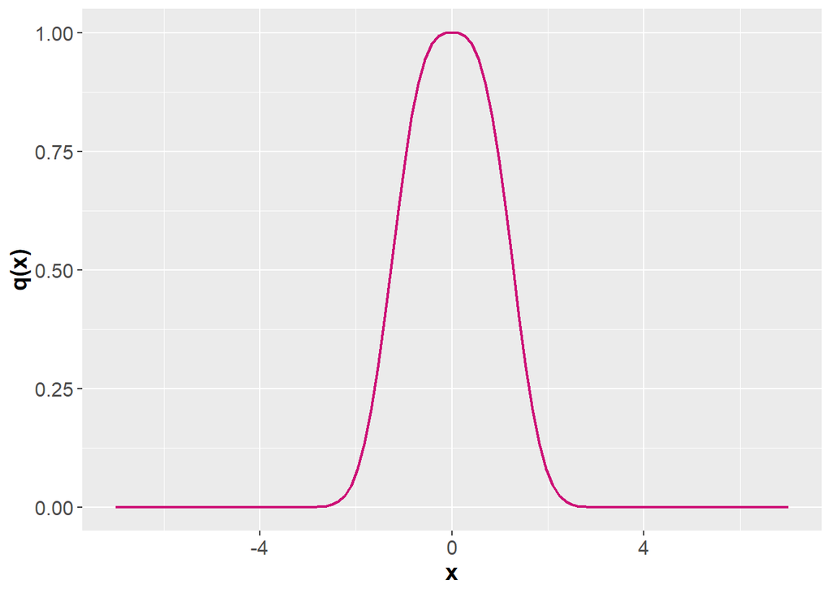

```r
rm(list=ls(all=TRUE))
library(ggplot2)

# Função densidade de probabilidade de Laplace (g(y): função auxiliar)
d_lap <-function(x) {
  return(0.5* exp(-abs(x)))
}

# Função kernel de densidade da v.a. X da qual se quer obter uma amostra
q_x <-function(x) {
  return(exp(-(abs(x)^3)/3))
}

# Gráfico de g(x)
ggplot() +
  xlim(-7,7) +
  geom_function(fun = d_lap, colour = "deepskyblue1",size = 0.75) +
  xlab("y") +
  ylab("g(y)") +
  theme(axis.text=element_text(size=12),
        axis.title=element_text(size=14,face="bold"))

# Gráfico de q(x)
ggplot() +
  xlim(-7,7) +
  geom_function(fun = q_x, colour = "deeppink3",size = 0.75) +
  xlab("x") +
  ylab("q(x)") +
  theme(axis.text=element_text(size=12),
        axis.title=element_text(size=14,face="bold"))
```

Tendo-se a função auxiliar $g(y)$, pode-se dar prosseguimento à implementação do método. Obtenhamos o valor de $M$ a partir do valor máximo assumido pela função $qg(x) = q(x)/g(x)$. Tal valor corresponde ao valor de $M$ ótimo para o problema. Analisemos o gráfico para a função $qg(x)$:

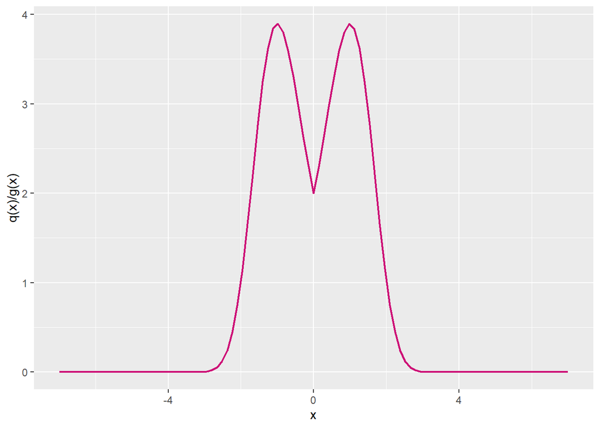

```r
# Função q(x)/g(x), da qual queremos obter o valor máximo para atribuir a M
qgx <-function(x) {
  return(q_x(x)/ d_lap(x))
  }


# Gráfico de q(x)/g(x)
ggplot() +
  xlim(-7,7) +
  geom_function(fun = qgx, colour = "deeppink3",size = 0.75) +
  xlab("x") +
  ylab("q(x)/g(x)")
```

Como $q(x)$ e $g(x)$ são simétricas, a função $qg(x)$ tambpem é simétrica, como pode ser confirmado pelo gráfico acima. Pode-se notar que existem 2 máximos globais para a função acima, os quais são iguais e, devido à simetria da função, são a imagem de dois valores no domínio que são iguais em módulo. Pode-se utilizar da função $optimize$ para obter o valor máquimo de $qg(x)$ e o valor positivo $x_0$ do domínio que leva a tal valor:

```r
# Obtenção do valor positivo de x que otimiza a função q(x)/g(x)
x_max <- optimize(qgx, interval=c(-7,7), maximum=TRUE)

M <- qgx(x_max$maximum)

cat("\n Valor máximo assumido por qg(x):", M,
    "\n Valor correspondente no domínio:", x_max$maximum)
```

```
##
##  Valor máximo assumido por qg(x): 3.895468
##  Valor correspondente no domínio: 1.000002
```

Assim, o valor ótimo obtido para a função (aproximadamente 3,89; obtido quando $x\in\{-1,1\}$) será atribuido à $M$ para a obtenção da função “cobertor” $Mg(x)$. Podemos visualizar o comportamento das duas funções ($q(x)$ e $Mg(x)$) em um mesmo gráfico para observar que de fato ocorre o envelopamento de $q(x)$.

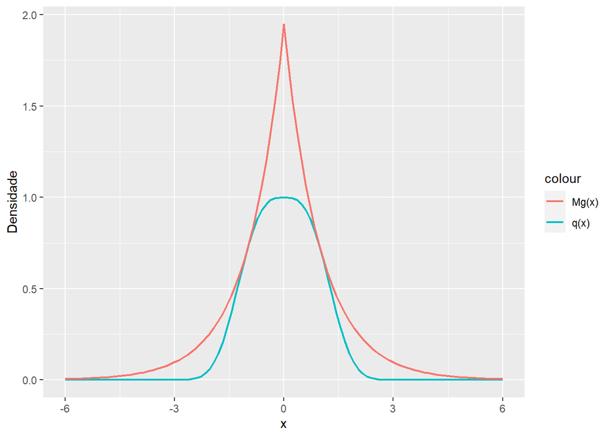

```r
# Função para Mg(x)
Mg_x <-function(x) {
  return(M*d_lap(x))
}

# Gráfico de q(x) e Mg(x)
ggplot() +
  xlim(-6,6) +
  geom_function(aes(colour = "q(x)"), fun = q_x, size = 0.75) +
  geom_function(aes(colour = "Mg(x)"), fun = Mg_x, size = 0.75) +
  xlab("x") +
  ylab("Densidade")
```

Assim sendo, podemos por fim criar uma função para obter uma amostra pseudoaleatória de $X$ por meio do método da aceitação-rejeição:

```r
sample_rej <- function(n){ # função recebe o tamanho da amostra n

  set.seed(2112) #setup da semente

  i <- n_t <- 0 # Inicialização do contador i para o tamanho da amostra e
  # do contador n_t para o número de tentativas

  a_X <- c() # vetor auxiliar para armazenamento dos valores observados de X

  while(i<n){ # laço para o tamanho da amostra, não é quebrado até o tamanho da
  # amostra ser n
   rej <- TRUE

    while(rej){ # laço para a rejeição, não é quebrado até que um valor seja  aceito
      n_t <- n_t + 1

      # obtenção de uma observação da variável auxiliar pelo método da inversão
      u <-runif(1)
      # a inversa da função de distribuição de Laplace padrão
      y <-ifelse(u<=0.5,log(2*u),-log(2*(1-u)))

      # condição de aceitação do valor observado para y: u <= q(x)/Mg(x),
      # sendo u ~ U(0,1).
      if(runif(1) <= qgx(y)/M){
        i <- i + 1
        a_X[i] <- y
        rej <- FALSE
      }
    }
  }
  cat("\n Tamanho da amostra:", i, "\n Número de tentativas:", n_t)
  return(a_X)
}
```

Agora utilizemos da função *sample_rej* para obter amostras pseudoaleatórias de $X$ de diferentes tamanhos:

```r
# Amostra n = 50
aa_50 <- sample_rej(50)
```

```
##
##  Tamanho da amostra: 50
##  Número de tentativas: 65
```

```r
# Amostra n = 100
aa_100 <- sample_rej(100)
```

```
##
##  Tamanho da amostra: 100
##  Número de tentativas: 147
```

```r
# Amostra n = 400
aa_400 <- sample_rej(400)
```

```
##
##  Tamanho da amostra: 400
##  Número de tentativas: 609
```

Podemos contruir os histogramas das amostras pseudoaleatórias de $X$ para visualizar a sua distribuição:

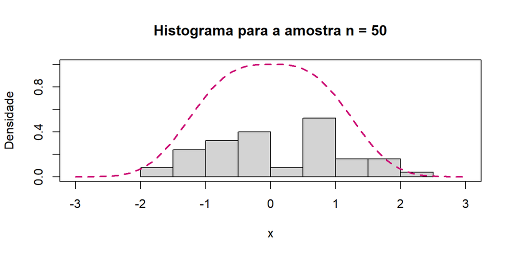

```r
hist(aa_50, freq = FALSE, main = "Histograma para a amostra n = 50",
     xlab = "x", ylab = "Densidade",
     xlim = c(-3,3), ylim = c(0,1))
curve(q_x, add = TRUE, lty = 2, col = "deeppink3", lwd = 2)
box()
```

repare que os valores da função $q(x)$ (linha rosa racejada) são mais elevados do que os valores do histograma, não ocorrendo uma melhor sobreposição. Isso se deve ao fato de $q(x)$ não ser uma função de densidade, mas sim o *kernel* de uma. De qualquer forma, pode-se compreender como os histogramas deveriam se comportar comparando-se com ela. Os histogramas para as outras amostras foram gerados da mesma forma que o acima e podem ser verificados abaixo.

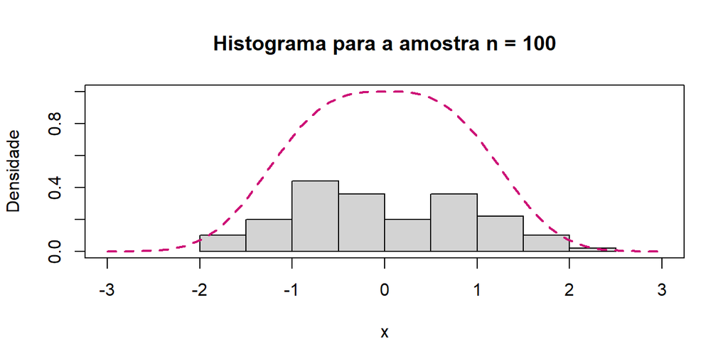

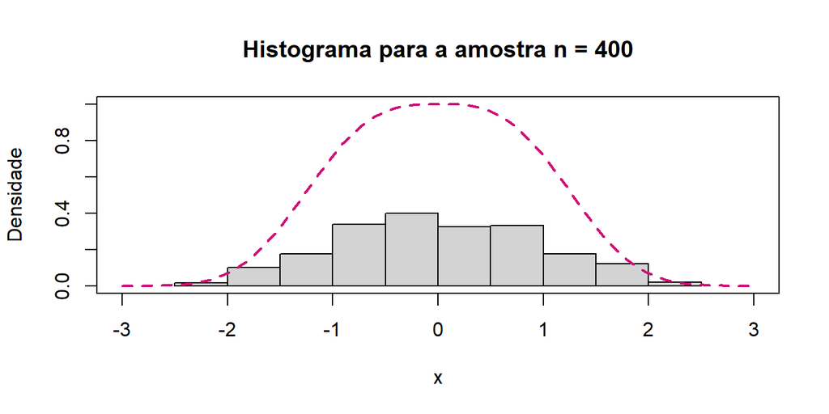

### Exercício 2

### Exercício 3